# Phenotypic forest package

Christophe Ladroue

2015-04-19

## Introduction

Phenotypic forest plots (phorests) are a way to present the effects of SNPs on a range of phenotypes. They facilitate the comparison of associations across SNPs, for example tagging different genes, over a number of phenotypes. If the number of SNPs is small (less than 15 or 20), all the associations are plotted. For large SNP sets, an alternative representation is available which shows the association statistics groups of SNPs.

This package also offers `polarHistogram()`, which can display a large number of histograms in a small space.

## Phorest

Phenotypic forest plots were originally designed for comparing the associations of SNPs to a list of phenotypes. The association data should be in a data frame with at least the columns:

- `phenotype`, `value`, `lowerBound`, `upperBound` and `SNP` for the default mode.
- `phenotype`, `value` and `SNP` if the number of SNPs is large `largeSNPSet = TRUE`.

If your data frame contains the necessary information but has different column names, you can use the argument `columnNames` to specify which ones correspond to the necessary columns.

### Small number of SNPs (default mode)

We first generate some toy data.

```r
randomWord<-function(n, nLetters = 5)
   replicate(n,paste(sample(letters, nLetters, replace = TRUE),sep = '', collapse=''))

toyData <- function(nPhenotype = 17, nSNP = 7, nPhenotypeGroups = 3 ){
  df <- data.frame(
    phenotype      = rep(randomWord(nPhenotype), 1, each = nSNP),
    value          = rep(1:nSNP, nPhenotype) + rnorm(nSNP * nPhenotype, mean = 0, sd = 0.1),
    lowerBound     = runif(nPhenotype * nSNP, min = 0.0, max = 0.1),
    upperBound     = runif(nPhenotype * nSNP, min = 0.0, max = 0.1),
    phenotypeGroup = rep(sample(toupper(randomWord(nPhenotypeGroups)), nPhenotype, replace = TRUE), 1, each = nSNP),
    SNP            = paste('rs',rep(sample(100000, nSNP), nPhenotype), sep = '')
    )

  df <- within(df, {
    lowerBound <- value - lowerBound
    upperBound <- value + upperBound}
             )
  df
}

set.seed(42)
nPhenotype <- 17
nSNP <- 7
nPhenotypeGroups <- 3

df <- toyData(nPhenotype, nSNP , nPhenotypeGroups)
print(head(df))
```

```
##   phenotype    value lowerBound upperBound phenotypeGroup     SNP
## 1     xyhvq 1.016022  0.9880415   1.052282          FBBHJ rs99600
## 2     xyhvq 1.865912  1.8094303   1.951426          FBBHJ rs80581
## 3     xyhvq 2.949055  2.8555410   2.979146          FBBHJ rs48624
## 4     xyhvq 3.650709  3.6148693   3.697276          FBBHJ rs53876
## 5     xyhvq 5.149878  5.0656769   5.164151          FBBHJ rs34103
## 6     xyhvq 6.062524  5.9902834   6.143296          FBBHJ  rs5202
```

This dataset contains 7 SNPs (Single Nucleotide Polymorphisms) and their relation (`value`) with 17 phenotypes. Each relation comes with a lower and upper bound. The phenotypes are grouped into 3 groups.

Running `phorest()` on this dataset produces the following plot:

```r
library(phenotypicForest)
phorest(df, connectingLines = TRUE)
```

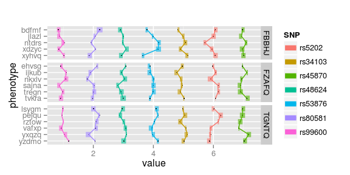

Each SNP is represented by its own colour. Each association value is a represented by a black dot. Each dot is in a small rectangle of the colour of the SNP and represents the uncertainty on that value. A connecting line helps in following and comparing SNPs over the list of phenotypes.

Phenotypes are shown on y-axis, in alphabetical order. It is often helpful to group them by theme, for example all phenotypes relating to lipids in one group, all phenotypes relating to muscle in another.

### Setting up phenotype groups

Phenotype groups can be set up in two ways:

- by specifying the group in the data frame directly, in the `phenotypeGroup` column.
- by using the `phenotypeGroups` argument in `phorest()` as a named list of phenotypes, of the form `list("group1"=c("phenotype5","phenotype3"...` etc.

```r
 set.seed(42)
 df <- toyData(10,1,3)
 print(df)
```

```
##    phenotype     value lowerBound upperBound phenotypeGroup     SNP
## 1      xyhvq 0.9569531  0.9526542  1.0151135          QFFKY rs53738
## 2      ntdrs 0.9742731  0.9602252  0.9900636          QFFKY rs53738
## 3      lsygm 0.8236837  0.8020451  0.8595865          QFFKY rs53738
## 4      yzdmo 1.0460097  0.9980699  1.1105729          TINTQ rs53738
## 5      xdzyc 0.9360005  0.9162595  1.0135828          RAFYY rs53738
## 6      nkxlv 1.0455450  0.9736094  1.1019097          TINTQ rs53738
## 7      tvkra 1.0704837  1.0696953  1.0938541          QFFKY rs53738
## 8      vafxp 1.1035104  1.0659614  1.1125084          QFFKY rs53738
## 9      jlazl 0.9391074  0.8876666  0.9476686          TINTQ rs53738
## 10     yxqzq 1.0504955  1.0503385  1.0810173          TINTQ rs53738
```

```r
 phorest(df)
```

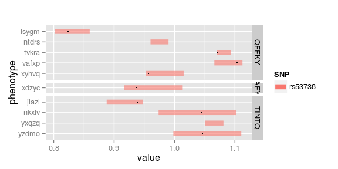

```r
 df$phenotypeGroup <- NULL # delete phenotypeGroup column

 userDefined <- list(
   "JONOSE" = c("xyhvq", "ntdrs", "lsygm", "yzdmo"),
   "RYBYGU" = c("xdzyc", "nkxlv", "tvkra"),
   "GYKUXU" = c("vafxp", "jlazl", "yxqzq"))

  phorest(df, phenotypeGroups = userDefined)
```

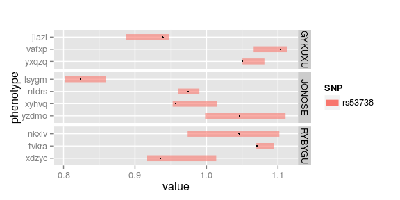

## Phorest for a large number of SNPs

If the number of SNPs to compare is large, it makes more sense to group them (*e.g.* by genes, pathway etc.) and plot some descriptive statistics instead. Defining the groups of SNPs is done in a similar fashion as defining groups of phenotypes:

- by specifying the group in the data frame directly, in the `SNPGroup` column.
- by using the `SNPGroups` argument in `phorest` as a named list of phenotypes, of the form `list("SNPgroup1" = c("rs1298371","rs129031"...` etc.

Here is an example on toy data:

```r
# creating some random SNP groups
set.seed(42)
nSNP <- 200
nSNPGroup <- 4
df <- toyData(17,nSNP,4)
df$value <- rnorm(nrow(df))
tmp <- data.frame(
  SNP = unique(df$SNP),
  SNPGroup = sample(paste0("SNP Group#", 1:nSNPGroup), nSNP, replace = TRUE))
df <- merge(df, tmp, by = "SNP")

head(df)
```

```
##       SNP phenotype      value lowerBound upperBound phenotypeGroup
## 1 rs10170     pejqu  1.5256130   124.8415   124.9486          QRFRX
## 2 rs10170     vafxp  1.0783985   124.8075   124.8881          QRFRX
## 3 rs10170     xyhvq  0.2553188   124.9545   125.0656          LVPYP
## 4 rs10170     ntdrs -0.3298275   125.1163   125.1974          LVPYP
## 5 rs10170     bdfmf  0.8210230   124.8838   125.0045          RRSXI
## 6 rs10170     sajna -0.1184251   125.0611   125.1003          RRSXI
##      SNPGroup
## 1 SNP Group#1
## 2 SNP Group#1
## 3 SNP Group#1
## 4 SNP Group#1
## 5 SNP Group#1
## 6 SNP Group#1
```

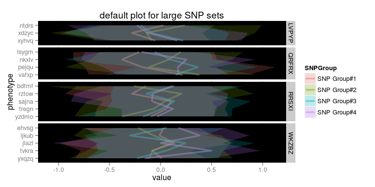

```r
phorest(
  df,
  largeSNPSet = TRUE,
  title = 'default plot for large SNP sets')
```

Each group of SNPs is represented by its distribution on the phenotypes. The default aggregating functions are median (for the line), and 25% and 75% quartiles (for the shaded area). You can define other statistics very easily, for example mean and standard deviation, with:

```r
# specifying the aggregating functions
phorest(
  df,
  largeSNPSet = TRUE,
  aggregatingFunction = function(x) mean(x, na.rm = TRUE),
  aggregatingLowerBound = function(x) mean(x, na.rm = TRUE) - sd(x, na.rm = TRUE),
  aggregatingUpperBound = function(x) mean(x, na.rm = TRUE) + sd(x, na.rm = TRUE),
  title = 'mean and standard deviation')
```

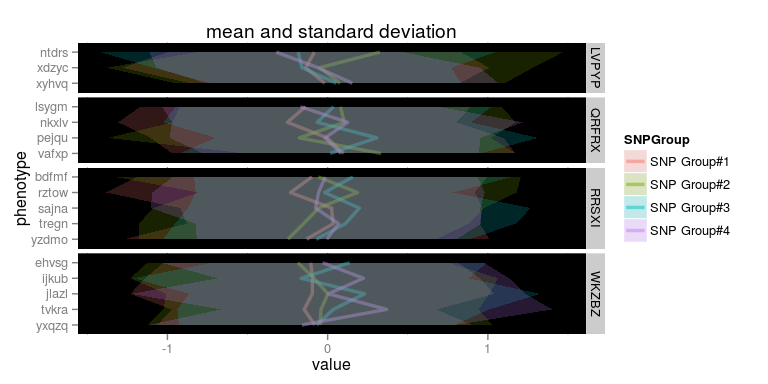

## polarHistogram

`polarHistogram` is useful for displaying a large number (about 100) of histograms in a small space. This plot was inspired by an illustration in Kettunen *et al.* 2012. The data must be in a data frame. The default column names are `family`, `item`, `score` and `value`. Each bar of the wheel shows the breakdown of `score` according to the corresponding `value`. Bars themselves are grouped into `family`.

```r
set.seed(42)
nFamily <- 20
nItemPerFamily <- sample(1:6, nFamily,replace = TRUE)
nValues <- 3

df <- data.frame(
  family = rep( randomWord(nFamily), times = nValues * nItemPerFamily),
  item   = rep( randomWord(sum(nItemPerFamily), 3), each = nValues ),
  score  = rep( paste0("V",1:nValues), times = sum(nItemPerFamily)),
  value  = round(500 * runif( sum(nItemPerFamily * nValues)),2))

print(head(df))
```

```
##   family item score  value
## 1  xdzyc  jko    V1 489.95
## 2  xdzyc  jko    V2 321.93
## 3  xdzyc  jko    V3 291.29
## 4  xdzyc  psk    V1 307.94
## 5  xdzyc  psk    V2 462.57
## 6  xdzyc  psk    V3 195.01
```

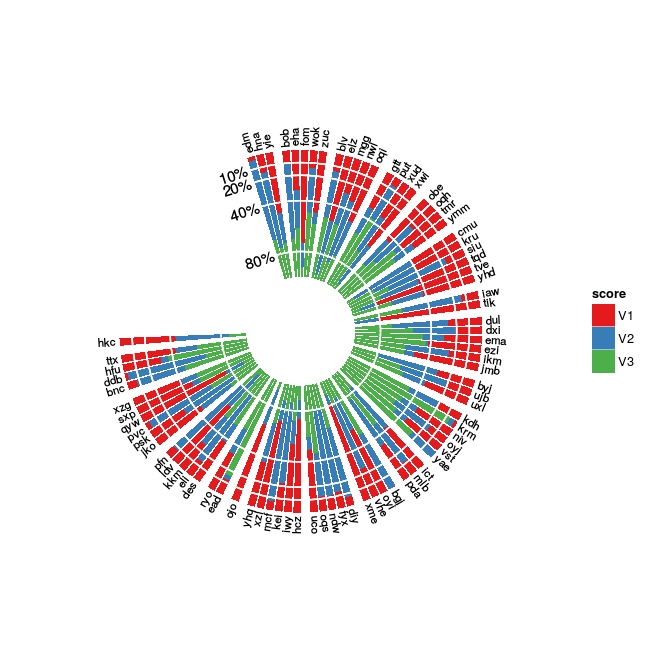

```r
polarHistogram(df, familyLabel = FALSE)
```

By default, each bar is normalised to 100%. For example, item `edm` has the following scores:

```r
df[df$item == 'edm',]
```

```
##     family item score  value
## 127  bdfmf  edm    V1  24.32
## 128  bdfmf  edm    V2 489.91
## 129  bdfmf  edm    V3 242.08
```

which gives the following height for the bars:

```r
100*df[df$item == 'edm',]$value/sum(df[df$item == 'edm',]$value)
```

```
## [1]  3.215613 64.776348 32.008039
```

as seen in the first bar. A white guide helps reading the values across the plot. By default it shows the 10%, 20%, 40% and 80% marks. This can be overriden with the argument `guides`.

It is possible to turn the normalisation off with `normalised = FALSE`. You might get some errors if the guides are not appropriate with the non-normalised values. For example, plotting the same data frame without normalisation yields:

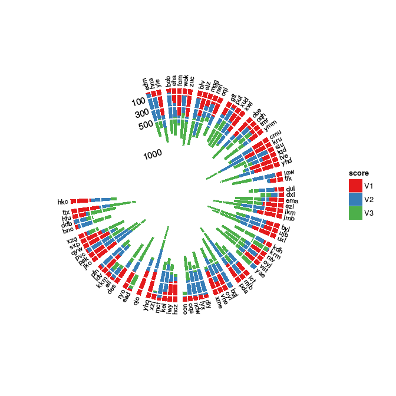

```r
polarHistogram(df, normalised = FALSE, guides = c(100,300,500,1000))
```

## Renaming the data frame’s columns

`phorest()` and `polarHistogram` require a data frame with specific columns. If your data frame doesn’t follow the same naming convention, you can simply use `columnNames` to indicate the name of the corresponding column in the function.

For example, suppose that you want to use `phorest()` but your data frame `df` has a column `snpid` instead of the expected `SNP` and a column `assays` instead of `phenotype`. Call `phorest()` as following:

```r
  # not run
  # p <- phorest(df, columnNames = c("SNP" = "snpid", "phenotype" = "assays))
```

## Modifying/saving phorests or polarHistograms

The graph is a `ggplot2` object and as such has all the properties of this type of object.

Saving the plot as a `png` or a `pdf` is done with `ggsave`: `ggsave("myPhorest.png",p)` or `ggsave("myPhorest.pdf",p)`, where `p` is the output of `phorest()` or `polarHistogram()`.

Adding a title, changing the axes label, the colour scheme etc. are also done like any `ggplot2` objects.

```r
#  p <- polarHistogram(df)
#  p <- p + ggtitle("put title here") + xlab("label for x-axis") + ylab("label for y-axis")
#  print(p)
```